# Financial Inclusion Problem in East Africa

**objective**  
Although there is numerous availabilty of mobile banking, Bank account is still needed for legal reasons, credit scoring etc. The aim of the project is to discover the prior reason many people in certain african country do not have a bank account. This could help the banking firm target specific audience in thier ad-placement and always make changes in the way the operate.

**data**  
The data used for this analysis contains thousands of rows of information of individuals such as the country they live, accessibility to cellphone, job type, age, household size, education level etc.

**expectation**

- people with less education level is likely to not have a bank account.
- people of the age less than 18 and greater than 70 is not likely to have a bank account.
- unemployed people is less likely to have a bank account etc.

**data analysis process**

- check the packaging
- check for counts
- check for distribution
- check for relations
- make pivot tables

```python
import pandas as pd
import numpy as np
import matplotlib.pyplot as plt
import seaborn as sns

plt.style.use('seaborn-whitegrid')
```

```python
data=pd.read_csv('data/data.csv')
```

```python
data.head()
```

|  | Country | Year | Bank account | Location Type | Access to cellphone | Household size | Age of respondent | Gender of respondent | Relation with head of the house | Marital status | Education level | Job type |
| --- | --- | --- | --- | --- | --- | --- | --- | --- | --- | --- | --- | --- |
| 0 | Kenya | 2018 | Yes | Rural | Yes | 3 | 24 | Female | Spouse | Married/Living together | Secondary education | Self employed |
| 1 | Kenya | 2018 | No | Rural | No | 5 | 70 | Female | Head of Household | Widowed | No formal education | Government Dependent |
| 2 | Kenya | 2018 | Yes | Urban | Yes | 5 | 26 | Male | Other relative | Single/Never Married | Vocational/Specialised training | Self employed |
| 3 | Kenya | 2018 | No | Rural | Yes | 5 | 34 | Female | Head of Household | Married/Living together | Primary education | Formally employed Private |
| 4 | Kenya | 2018 | No | Urban | No | 8 | 26 | Male | Child | Single/Never Married | Primary education | Informally employed |

```python
data.info()
```

```
<class 'pandas.core.frame.DataFrame'>
RangeIndex: 23524 entries, 0 to 23523
Data columns (total 12 columns):
 #   Column                           Non-Null Count  Dtype
---  ------                           --------------  -----
 0   Country                          23524 non-null  object
 1   Year                             23524 non-null  int64
 2   Bank account                     23524 non-null  object
 3   Location Type                    23524 non-null  object
 4   Access to cellphone              23524 non-null  object
 5   Household size                   23524 non-null  int64
 6   Age of respondent                23524 non-null  int64
 7   Gender of respondent             23524 non-null  object
 8   Relation with head of the house  23524 non-null  object
 9   Marital status                   23524 non-null  object
 10  Education level                  23524 non-null  object
 11  Job type                         23524 non-null  object
dtypes: int64(3), object(9)
memory usage: 2.2+ MB
```

```python
data.isna().sum()
```

```
Country                            0
Year                               0
Bank account                       0
Location Type                      0
Access to cellphone                0
Household size                     0
Age of respondent                  0
Gender of respondent               0
Relation with head of the house    0
Marital status                     0
Education level                    0
Job type                           0
dtype: int64
```

```python
print('Number of rows: ', data.shape[0])
print('Number of columns: ', data.shape[1])
```

```
Number of rows:  23524
Number of columns:  12
```

```python
# how many people had bank account in the data.
data.groupby('Bank account')['Bank account'].agg(['count'])
```

| Bank account | count |
| --- | --- |
| No | 20212 |
| Yes | 3312 |

```python
data['Bank account'].value_counts(normalize=True)
```

```
No     0.859208
Yes    0.140792
Name: Bank account, dtype: float64
```

```python
no_account= data[data['Bank account'] == 'No']
account= data[data['Bank account'] == 'Yes']
```

# Cellphone access

```python
data.groupby(['Bank account','Access to cellphone'])\
   [ 'Access to cellphone'].agg(['count'])/data.shape[0]
```

| Bank account | Access to cellphone | count |
| --- | --- | --- |
| No | No | 0.253613 |
|  | Yes | 0.605594 |
| Yes | No | 0.004421 |
|  | Yes | 0.136371 |

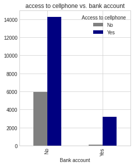

```python
pd.crosstab(data['Bank account'],
            data['Access to cellphone']).\
plot(kind='bar', figsize=(4, 5), \
     title='access to cellphone vs. bank account', color=['grey', 'navy'])
plt.savefig('images/accessto cellpohne1.png')
```

# age of respondent

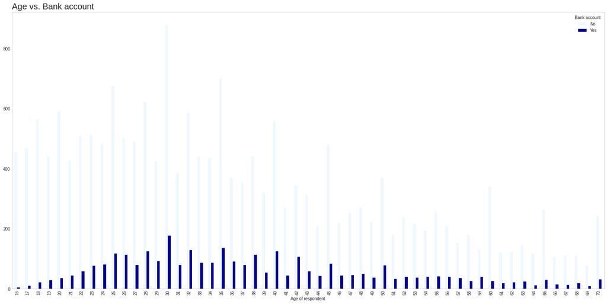

```python
df = data[data['Age of respondent'].between(15, 70)]
g= pd.crosstab(df['Age of respondent'],
            df['Bank account']).\
           plot(kind='bar', figsize=(25, 12), grid=False, color=['aliceblue', 'darkblue'])
g.set_title('Age vs. Bank account', size=20, loc='left')
plt.savefig('images/age0.png')
```

```python
# Age
sample_data=data.sample(n=300)
print("population mean of ages: ", np.round(data['Age of respondent'].mean(), 2))
print('sample mean of ages: ', np.round(sample_data['Age of respondent'].mean(), 2))
```

```
population mean of ages:  38.81
sample mean of ages:  39.72
```

```python
# test if the mean age is any different from 38
```

```python
list(data)
```

```
['Country',
 'Year',
 'Bank account',
 'Location Type',
 'Access to cellphone',
 'Household size',
 'Age of respondent',
 'Gender of respondent',
 'Relation with head of the house',
 'Marital status',
 'Education level',
 'Job type']
```

```python
# differences between age of genders

data.groupby('Gender of respondent')['Age of respondent'].agg(['mean', 'median'])
```

| Gender of respondent | mean | median |
| --- | --- | --- |
| Female | 38.629675 | 35 |
| Male | 39.057738 | 36 |

```python
data.dtypes
```

```
Country                            object
Year                                int64
Bank account                       object
Location Type                      object
Access to cellphone                object
Household size                      int64
Age of respondent                   int64
Gender of respondent               object
Relation with head of the house    object
Marital status                     object
Education level                    object
Job type                           object
dtype: object
```

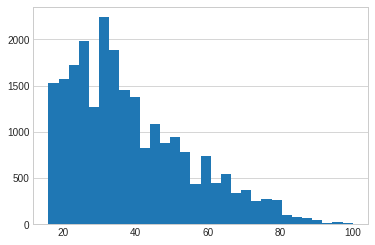

```python
plt.hist(data['Age of respondent'], bins=30, );
plt.grid(axis='x')
```

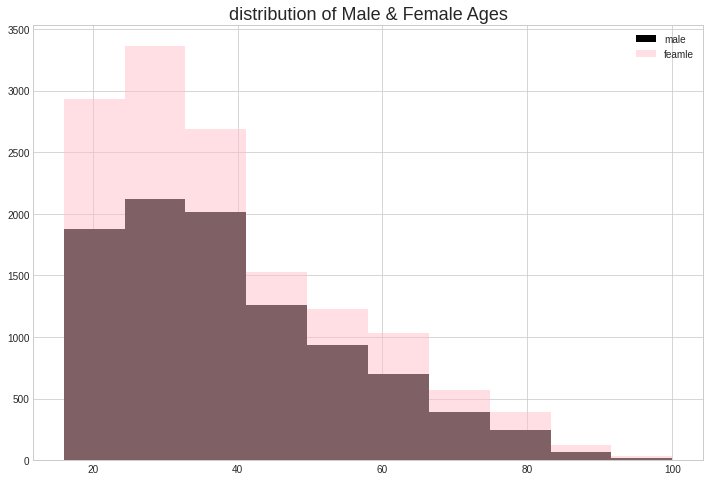

```python
plt.figure(figsize=(12, 8))
plt.hist(data[data['Gender of respondent']=='Male']['Age of respondent'], label='male', color='black');
plt.hist(data[data['Gender of respondent']=='Female']['Age of respondent'],
         color='pink', alpha=.5, label='feamle');
plt.legend()
plt.title('distribution of Male & Female Ages', size=18)
```

```python
# chebychevs' rule
mean_age= data['Age of respondent'].mean()
std_age= data['Age of respondent'].std()

print('1. 75% of individuals have ages between ', np.floor(mean_age-2*std_age), ' and ',
      np.floor(mean_age+2*std_age))
print('2. 88.89% of individuals have ages between ', np.floor(mean_age-2*std_age), ' and ',
      np.floor(mean_age+3*std_age))
```

```
1. 75% of individuals have ages between  5.0  and  71.0
2. 88.89% of individuals have ages between  5.0  and  88.0
```

```python
pd.DataFrame(data['Age of respondent'].describe([.25, .5, .75, .95])).round(2)
```

|  | Age of respondent |
| --- | --- |
| count | 23524.00 |
| mean | 38.81 |
| std | 16.52 |
| min | 16.00 |
| 25% | 26.00 |
| 50% | 35.00 |
| 75% | 49.00 |
| 95% | 71.00 |
| max | 100.00 |

```python
# confidence interval of ages (of population mean)

mu = data['Age of respondent'].mean()
sd_age = data['Age of respondent'].std()
se = sd_age/np.sqrt(data['Age of respondent'].count())
ci = mu-1.96*se, mu+1.96*se
print('Confidence Interval of mean ages id between ',np.floor(ci)[0], ' and ', np.floor(ci)[1] )
```

```
Confidence Interval of mean ages id between  38.0  and  39.0
```

# household size

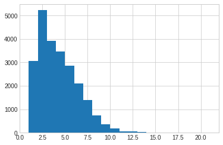

```python
data['Household size'].hist( bins=20)
```

```python
#assert (data['Household size'] <0).any(), 'house size is greater than 0'
```

```python
# chebychevs' rule
mean_hsize= data['Household size'].mean()
std_hsize= data['Household size'].std()

print('1. 75% of the people live in the household between ', np.floor(mean_hsize-2*std_hsize), ' and ',
      np.floor(mean_hsize+2*std_hsize))
print('2. 88.89% of the people live in the household between ', np.floor(mean_hsize-2*std_hsize), ' and ',
      np.floor(mean_hsize+3*std_hsize))
```

```
1. 75% of the people live in the household between  -1.0  and  8.0
2. 88.89% of the people live in the household between  -1.0  and  10.0
```

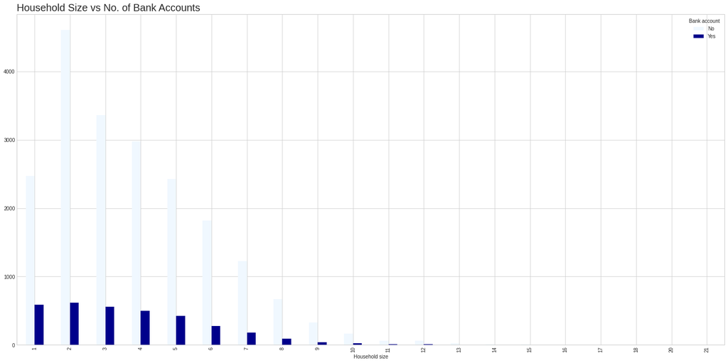

```python
g = pd.crosstab(data['Household size'], data['Bank account']).plot(kind='bar',
                                                               color=['aliceblue', 'darkblue'],
                                                               figsize=(25, 12))
g.set_title('Household Size vs No. of Bank Accounts', size=20, loc='left')
plt.savefig('images/household3.png')
```

# Country

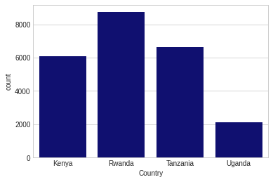

```python
sns.countplot(x= data['Country'], color='navy')
```

```python
pd.DataFrame([data.groupby(['Country', 'Bank account'])['Bank account'].count(),
             data.groupby(['Country', 'Bank account'])['Bank account'].count()/data.shape[0]],
            index=['Count', 'Percentage']).T
```

| Country | Bank account | Count | Percentage |
| --- | --- | --- | --- |
| Kenya | No | 4547.0 | 0.193292 |
|  | Yes | 1521.0 | 0.064657 |
| Rwanda | No | 7732.0 | 0.328686 |
|  | Yes | 1003.0 | 0.042637 |
| Tanzania | No | 6013.0 | 0.255611 |
|  | Yes | 607.0 | 0.025803 |
| Uganda | No | 1920.0 | 0.081619 |
|  | Yes | 181.0 | 0.007694 |

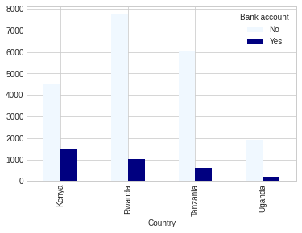

```python
pd.crosstab(data['Country'], data['Bank account']).plot(kind='bar', color=['aliceblue', 'navy'])
```

```python
data.head()
```

|  | Country | Year | Bank account | Location Type | Access to cellphone | Household size | Age of respondent | Gender of respondent | Relation with head of the house | Marital status | Education level | Job type |
| --- | --- | --- | --- | --- | --- | --- | --- | --- | --- | --- | --- | --- |
| 0 | Kenya | 2018 | Yes | Rural | Yes | 3 | 24 | Female | Spouse | Married/Living together | Secondary education | Self employed |
| 1 | Kenya | 2018 | No | Rural | No | 5 | 70 | Female | Head of Household | Widowed | No formal education | Government Dependent |
| 2 | Kenya | 2018 | Yes | Urban | Yes | 5 | 26 | Male | Other relative | Single/Never Married | Vocational/Specialised training | Self employed |
| 3 | Kenya | 2018 | No | Rural | Yes | 5 | 34 | Female | Head of Household | Married/Living together | Primary education | Formally employed Private |
| 4 | Kenya | 2018 | No | Urban | No | 8 | 26 | Male | Child | Single/Never Married | Primary education | Informally employed |

```python
list(data.select_dtypes('object'))
```

```
['Country',
 'Bank account',
 'Location Type',
 'Access to cellphone',
 'Gender of respondent',
 'Relation with head of the house',
 'Marital status',
 'Education level',
 'Job type']
```

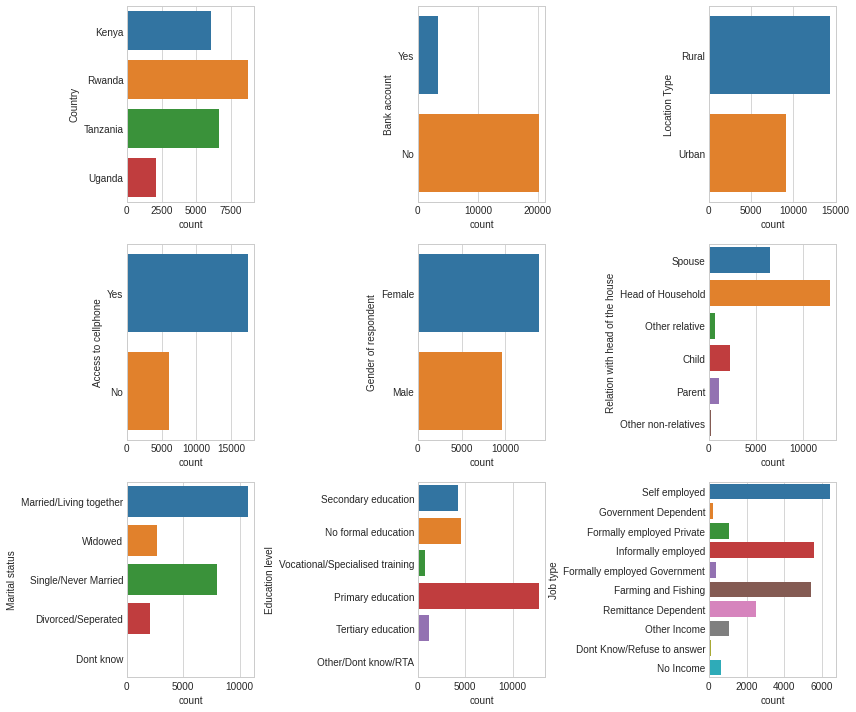

```python
plt.figure(figsize=(12, 10))
for index, columns in enumerate(list(data.select_dtypes('object'))):
    plt.subplot(3, 3, index+1)
    plt.tight_layout()
    sns.countplot(y = data[columns])
```

# Job

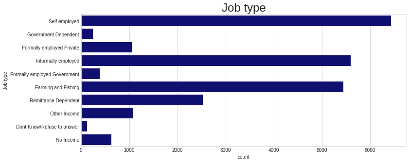

```python
f, ax = plt.subplots(figsize=(12, 5))
sns.countplot(y = data['Job type'], ax=ax, color='navy')
plt.title('Job type', size=24)
```

```python
pd.crosstab(data['Job type'], data['Bank account'])
```

| Bank account Job type | No | Yes |
| --- | --- | --- |
| Dont Know/Refuse to answer | 112 | 14 |
| Farming and Fishing | 4806 | 635 |
| Formally employed Government | 87 | 300 |
| Formally employed Private | 484 | 571 |
| Government Dependent | 197 | 50 |
| Informally employed | 5152 | 445 |
| No Income | 614 | 13 |
| Other Income | 884 | 196 |
| Remittance Dependent | 2287 | 240 |
| Self employed | 5589 | 848 |

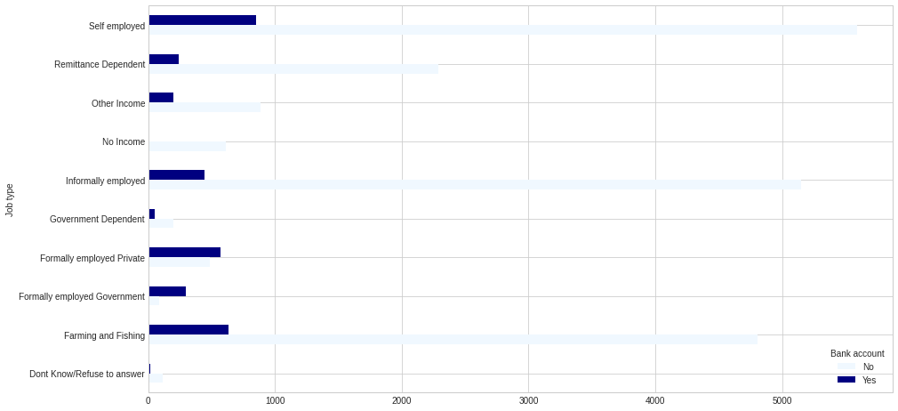

```python
pd.crosstab(data['Job type'], data['Bank account'])\
.plot(kind='barh', figsize=(15, 8), color=['aliceblue', 'navy'])
```

```python
data['Job type'].unique()
```

```
array(['Self employed', 'Government Dependent',
       'Formally employed Private', 'Informally employed',
       'Formally employed Government', 'Farming and Fishing',
       'Remittance Dependent', 'Other Income',
       'Dont Know/Refuse to answer', 'No Income'], dtype=object)
```

```python
job_type_reduced= data[['Country','Gender of respondent','Job type', 'Location Type','Bank account',]]
job_type_reduced
```

|  | Country | Gender of respondent | Job type | Location Type | Bank account |
| --- | --- | --- | --- | --- | --- |
| 0 | Kenya | Female | Self employed | Rural | Yes |
| 1 | Kenya | Female | Government Dependent | Rural | No |
| 2 | Kenya | Male | Self employed | Urban | Yes |
| 3 | Kenya | Female | Formally employed Private | Rural | No |
| 4 | Kenya | Male | Informally employed | Urban | No |
| ... | ... | ... | ... | ... | ... |
| 23519 | Uganda | Female | Other Income | Rural | No |
| 23520 | Uganda | Female | Other Income | Rural | No |
| 23521 | Uganda | Female | Other Income | Rural | No |
| 23522 | Uganda | Female | Self employed | Urban | No |
| 23523 | Uganda | Male | No Income | Rural | No |

23524 rows × 5 columns

```python
job_type_reduced['Job type'] = \
np.where(job_type_reduced['Job type'].isin(['Self employed', 'Formally employed Private',
                                            'Informally employed', 'Formally employed Government',
                                            'Farming and Fishing',]), 'Has Job', job_type_reduced['Job type'] )

job_type_reduced['Job type']= np.where(job_type_reduced['Job type'].isin(['Government Dependent',
                                                                          'Remittance Dependent']), 'Dependent',
                                      job_type_reduced['Job type']);
```

```python
job_type_reduced['Job type'].unique()
```

```
array(['Has Job', 'Dependent', 'Other Income',
       'Dont Know/Refuse to answer', 'No Income'], dtype=object)
```

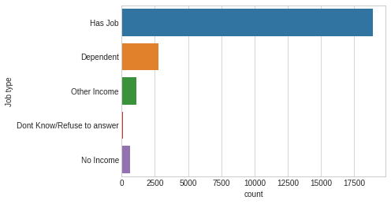

```python
sns.countplot(y=job_type_reduced['Job type'])
```

```python
pd.concat([job_type_reduced['Job type'].value_counts(),
           job_type_reduced['Job type'].value_counts(normalize=True),], axis=1)
```

|  | Job type | Job type |
| --- | --- | --- |
| Has Job | 18917 | 0.804157 |
| Dependent | 2774 | 0.117922 |
| Other Income | 1080 | 0.045911 |
| No Income | 627 | 0.026654 |
| Dont Know/Refuse to answer | 126 | 0.005356 |

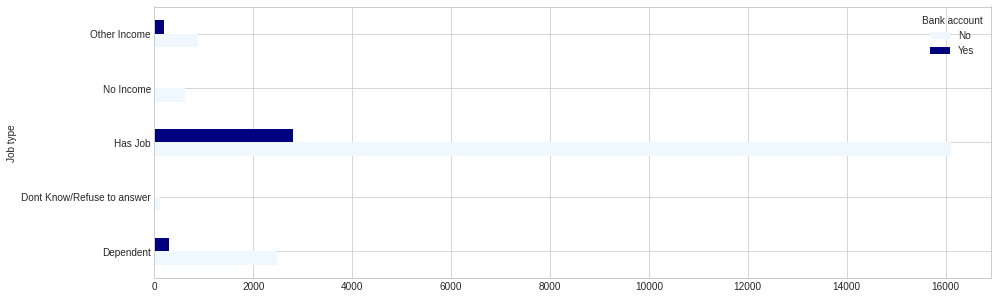

```python
pd.crosstab(job_type_reduced['Job type'], job_type_reduced['Bank account']).\
plot(kind='barh', figsize=(15, 5), color=['aliceblue', 'navy'])
plt.savefig('images/job.png')
```

# Education

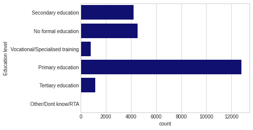

```python
sns.countplot(y = data['Education level'], color='navy')
```

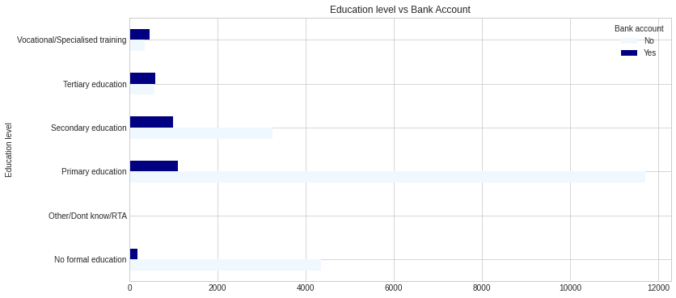

```python
pd.crosstab(data['Education level'], data['Bank account']).\
plot(kind='barh', figsize=(12, 6), title='Education level vs Bank Account', color=['aliceblue', 'navy'])
```

```python
pd.crosstab(data['Education level'], data['Bank account'])
```

| Bank account Education level | No | Yes |
| --- | --- | --- |
| No formal education | 4339 | 176 |
| Other/Dont know/RTA | 24 | 11 |
| Primary education | 11698 | 1093 |
| Secondary education | 3240 | 983 |
| Tertiary education | 566 | 591 |
| Vocational/Specialised training | 345 | 458 |

```python
list(data.select_dtypes(['int', 'float']))
```

```
['Year', 'Household size', 'Age of respondent']
```

# Gender

```python
pd.crosstab(data['Gender of respondent'], data['Bank account'])
```

| Bank account Gender of respondent | No | Yes |
| --- | --- | --- |
| Female | 12395 | 1482 |
| Male | 7817 | 1830 |

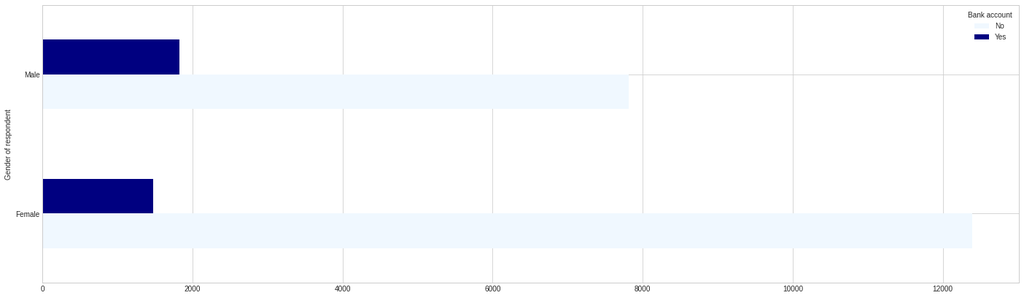

```python
pd.crosstab(data['Gender of respondent'], data['Bank account'])\
.plot(kind='barh', figsize=(24, 7), color=['aliceblue', 'navy'])
plt.savefig('images/gender1.png')
```

# Marital status

```python
data.head()
```

|  | Country | Year | Bank account | Location Type | Access to cellphone | Household size | Age of respondent | Gender of respondent | Relation with head of the house | Marital status | Education level | Job type |
| --- | --- | --- | --- | --- | --- | --- | --- | --- | --- | --- | --- | --- |
| 0 | Kenya | 2018 | Yes | Rural | Yes | 3 | 24 | Female | Spouse | Married/Living together | Secondary education | Self employed |
| 1 | Kenya | 2018 | No | Rural | No | 5 | 70 | Female | Head of Household | Widowed | No formal education | Government Dependent |
| 2 | Kenya | 2018 | Yes | Urban | Yes | 5 | 26 | Male | Other relative | Single/Never Married | Vocational/Specialised training | Self employed |
| 3 | Kenya | 2018 | No | Rural | Yes | 5 | 34 | Female | Head of Household | Married/Living together | Primary education | Formally employed Private |
| 4 | Kenya | 2018 | No | Urban | No | 8 | 26 | Male | Child | Single/Never Married | Primary education | Informally employed |

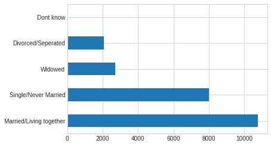

```python
data['Marital status'].value_counts().plot(kind='barh', )
```

```python
marital = data[['Marital status', 'Bank account']]
```

```python
marital['Marital status'].unique()
```

```
array(['Married/Living together', 'Widowed', 'Single/Never Married',
       'Divorced/Seperated', 'Dont know'], dtype=object)
```

```python
marital['Marital status'] = np.where(marital['Marital status'].isin(['Married/Living together',
                                                                     'Widowed', 'Divorced/Seperated']),
                                                                      'Married Before', marital['Marital status'])
```

```python
marital['Marital status'].unique()
```

```
array(['Married Before', 'Single/Never Married', 'Dont know'],
      dtype=object)
```

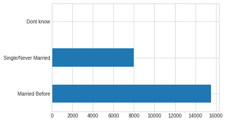

```python
marital['Marital status'].value_counts().plot(kind='barh')
```

```python
marital['Marital status'].value_counts()
```

```
Married Before          15533
Single/Never Married     7983
Dont know                   8
Name: Marital status, dtype: int64
```

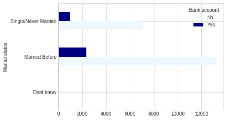

```python
pd.crosstab(marital['Marital status'], marital['Bank account']).plot(kind='barh',
                                                                     color=['aliceblue', 'navy'])
```

```python
data.head()
```

|  | Country | Year | Bank account | Location Type | Access to cellphone | Household size | Age of respondent | Gender of respondent | Relation with head of the house | Marital status | Education level | Job type |
| --- | --- | --- | --- | --- | --- | --- | --- | --- | --- | --- | --- | --- |
| 0 | Kenya | 2018 | Yes | Rural | Yes | 3 | 24 | Female | Spouse | Married/Living together | Secondary education | Self employed |
| 1 | Kenya | 2018 | No | Rural | No | 5 | 70 | Female | Head of Household | Widowed | No formal education | Government Dependent |
| 2 | Kenya | 2018 | Yes | Urban | Yes | 5 | 26 | Male | Other relative | Single/Never Married | Vocational/Specialised training | Self employed |
| 3 | Kenya | 2018 | No | Rural | Yes | 5 | 34 | Female | Head of Household | Married/Living together | Primary education | Formally employed Private |
| 4 | Kenya | 2018 | No | Urban | No | 8 | 26 | Male | Child | Single/Never Married | Primary education | Informally employed |

# Location

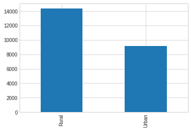

```python
data['Location Type'].value_counts().plot(kind='bar')
```

pd.pivot_table( data, values=None, index=None, columns=None, aggfunc='mean', fill_value=None, margins=False, dropna=True, margins_name='All', observed=False, ) -> 'DataFrame'

```python
df = job_type_reduced.drop('Gender of respondent', axis=1)
pivot= pd.pivot_table(aggfunc=np.count_nonzero,
                      index=['Location Type', 'Job type'],
                      columns=['Bank account'], data=df)
```

```python
list(df)
```

```
['Country', 'Job type', 'Location Type', 'Bank account']
```

```python
pivot
```

| Location Type | Bank account Job type | Country No | Country Yes |
| --- | --- | --- | --- |
| Rural | Dependent | 1370 | 131 |
|  | Dont Know/Refuse to answer | 88 | 8 |
|  | Has Job | 10353 | 1462 |
|  | No Income | 289 | 10 |
|  | Other Income | 572 | 60 |
| Urban | Dependent | 1114 | 159 |
|  | Dont Know/Refuse to answer | 24 | 6 |
|  | Has Job | 5765 | 1337 |
|  | No Income | 325 | 3 |
|  | Other Income | 312 | 136 |

```python
pivot.shape
```

```
(10, 2)
```

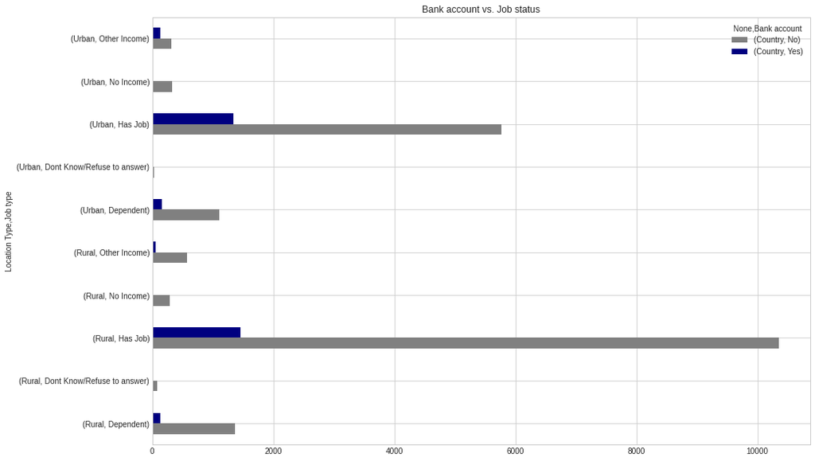

```python
pivot.plot(kind='barh', figsize=(15, 10), color=['grey', 'navy', 'grey', 'navy'],
           title='Bank account vs. Job status')
```

```python
location= pd.DataFrame([data['Location Type'].value_counts(),
                        data['Location Type'].value_counts(normalize=True)], index=['count', 'pct']).T.round(2)
location
```

|  | count | pct |
| --- | --- | --- |
| Rural | 14343.0 | 0.61 |
| Urban | 9181.0 | 0.39 |

```python
data.head()
```

|  | Country | Year | Bank account | Location Type | Access to cellphone | Household size | Age of respondent | Gender of respondent | Relation with head of the house | Marital status | Education level | Job type |
| --- | --- | --- | --- | --- | --- | --- | --- | --- | --- | --- | --- | --- |
| 0 | Kenya | 2018 | Yes | Rural | Yes | 3 | 24 | Female | Spouse | Married/Living together | Secondary education | Self employed |
| 1 | Kenya | 2018 | No | Rural | No | 5 | 70 | Female | Head of Household | Widowed | No formal education | Government Dependent |
| 2 | Kenya | 2018 | Yes | Urban | Yes | 5 | 26 | Male | Other relative | Single/Never Married | Vocational/Specialised training | Self employed |
| 3 | Kenya | 2018 | No | Rural | Yes | 5 | 34 | Female | Head of Household | Married/Living together | Primary education | Formally employed Private |
| 4 | Kenya | 2018 | No | Urban | No | 8 | 26 | Male | Child | Single/Never Married | Primary education | Informally employed |

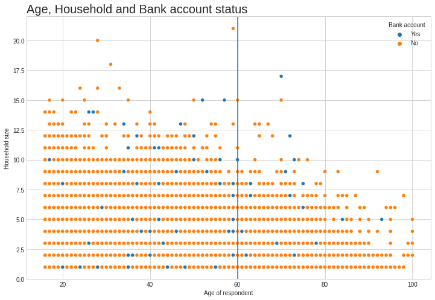

```python
f, ax=plt.subplots(figsize=(12, 8))
sns.scatterplot(data=data, x = 'Age of respondent', y='Household size',
                x_jitter=True,
                y_jitter=True,
                hue='Bank account',
               ax = ax)
plt.axvline(x=60)
plt.title('Age, Household and Bank account status', size=20, loc='left')
plt.savefig('images/age1.png')
```

```python
data.head()
```

|  | Country | Year | Bank account | Location Type | Access to cellphone | Household size | Age of respondent | Gender of respondent | Relation with head of the house | Marital status | Education level | Job type |
| --- | --- | --- | --- | --- | --- | --- | --- | --- | --- | --- | --- | --- |
| 0 | Kenya | 2018 | Yes | Rural | Yes | 3 | 24 | Female | Spouse | Married/Living together | Secondary education | Self employed |
| 1 | Kenya | 2018 | No | Rural | No | 5 | 70 | Female | Head of Household | Widowed | No formal education | Government Dependent |
| 2 | Kenya | 2018 | Yes | Urban | Yes | 5 | 26 | Male | Other relative | Single/Never Married | Vocational/Specialised training | Self employed |
| 3 | Kenya | 2018 | No | Rural | Yes | 5 | 34 | Female | Head of Household | Married/Living together | Primary education | Formally employed Private |
| 4 | Kenya | 2018 | No | Urban | No | 8 | 26 | Male | Child | Single/Never Married | Primary education | Informally employed |

```python
sns.heatmap?
```

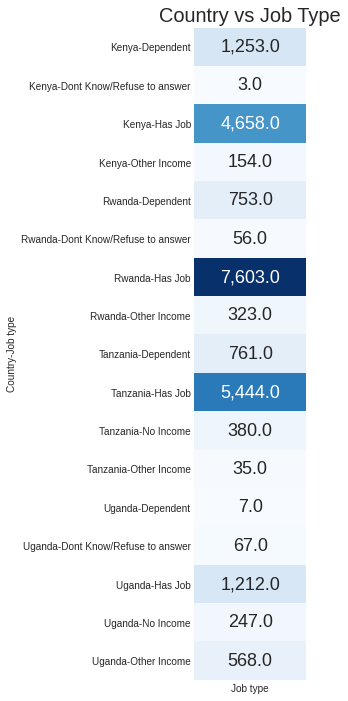

```python
# country vs. job type..
f, ax=plt.subplots(figsize=(2, 12))
sns.heatmap(data=pd.DataFrame(job_type_reduced.groupby(['Country', 'Job type'])['Job type'].count()),
           annot=True,
            annot_kws= {'size': 18},
            fmt= ',.1f',
            cbar=False,
           ax=ax,
           cmap='Blues',)
plt.title('Country vs Job Type', size=20)
```

```python
data.groupby('Country')['Age of respondent'].agg(['mean', 'median'])
```

| Country | mean | median |
| --- | --- | --- |
| Kenya | 39.616348 | 35 |
| Rwanda | 39.292959 | 35 |
| Tanzania | 38.479607 | 35 |
| Uganda | 35.460733 | 31 |

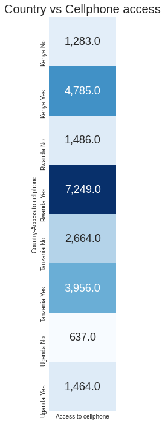

```python
f, ax=plt.subplots(figsize=(2, 12))
sns.heatmap(data=pd.DataFrame(data.groupby(['Country', 'Access to cellphone'])['Access to cellphone'].count()),
           annot=True,
            annot_kws= {'size': 18},
            fmt= ',.1f',
            cbar=False,
           ax=ax,
           cmap='Blues',)
plt.title('Country vs Cellphone access', size=20)
```

```python
data['Education level'].unique()
```

```
array(['Secondary education', 'No formal education',
       'Vocational/Specialised training', 'Primary education',
       'Tertiary education', 'Other/Dont know/RTA'], dtype=object)
```

```python
edu= data
edu['Education level']= np.where(data['Education level'].isin(['Secondary education',
                                            'Primary education',
                                            'Tertiary education']), 'Formal Education', data['Education level'])
```

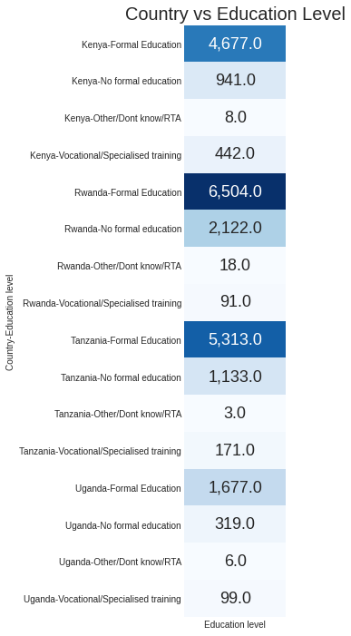

```python
f, ax=plt.subplots(figsize=(2, 12))
sns.heatmap(data=pd.DataFrame(edu.groupby(['Country', 'Education level'])['Education level'].count()),
           annot=True,
            annot_kws= {'size': 18},
            fmt= ',.1f',
            cbar=False,
           ax=ax,
           cmap='Blues',)
plt.title('Country vs Education Level', size=20)
```

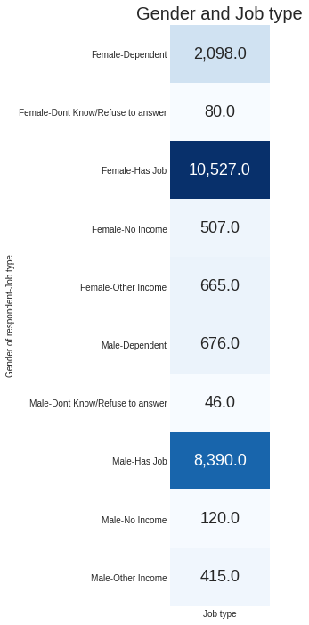

```python
f, ax=plt.subplots(figsize=(2, 12))
sns.heatmap(data=pd.DataFrame(job_type_reduced.groupby(['Gender of respondent', 'Job type'])['Job type'].count()),
           annot=True,
            annot_kws= {'size': 18},
            fmt= ',.1f',
            cbar=False,
           ax=ax,
           cmap='Blues',)
plt.title('Gender and Job type', size=20)
```

```python
data['Location Type'].unique()
```

```
array(['Rural', 'Urban'], dtype=object)
```

```python
pd.DataFrame([data[data['Location Type'] == 'Rural']['Age of respondent'].\
             describe(percentiles=[.25, .5, .75, .9, .95]),
             data[data['Location Type'] == 'Urban']['Age of respondent'].\
             describe(percentiles=[.25, .5, .75, .9, .95])], index=['Rural Area', 'Urban Area'])
```

|  | count | mean | std | min | 25% | 50% | 75% | 90% | 95% | max |
| --- | --- | --- | --- | --- | --- | --- | --- | --- | --- | --- |
| Rural Area | 14343.0 | 39.431360 | 16.712862 | 16.0 | 27.0 | 35.0 | 50.0 | 65.0 | 72.0 | 100.0 |
| Urban Area | 9181.0 | 37.827034 | 16.168036 | 16.0 | 25.0 | 34.0 | 47.0 | 62.0 | 70.0 | 100.0 |

```python
data.groupby(['Relation with head of the house'])['Household size'].agg(['mean', 'median']).round(2)
```

| Relation with head of the house | mean | median |
| --- | --- | --- |
| Child | 5.19 | 5 |
| Head of Household | 3.26 | 3 |
| Other non-relatives | 4.46 | 4 |
| Other relative | 4.15 | 4 |
| Parent | 4.67 | 4 |
| Spouse | 4.18 | 4 |